# Regression Model for [Project Name] Using R version 06

## 4. Model and Evaluate Algorithms

After the data-prep, we next work on finding a workable model by evaluating a subset of machine learning algorithms that are good at exploiting the structure of the dataset. The typical evaluation tasks include:

- Defining test options such as cross validation and the evaluation metric to use.
- Spot checking a suite of linear and nonlinear machine learning algorithms.
- Comparing the estimated accuracy of algorithms.

For this project, we will evaluate four linear, three non-linear, and three ensemble algorithms:

Linear Algorithm: Linear Regression, Ridge, The Lasso, Elasticnet

Non-Linear Algorithms: Decision Trees (CART), k-Nearest Neighbors, and Support Vector Machine

Ensemble Algorithms: Bagged CART, Random Forest, and Stochastic Gradient Boosting

The random number seed is reset before each run to ensure that the evaluation of each algorithm is performed using the same data splits. It ensures the results are directly comparable.

### 4.a) Generate models using linear algorithms

```r
# Linear Regression (Regression)
email_notify(paste("Linear Regression modeling has begun!",date()))
```

```
## [1] "Java-Object{org.apache.commons.mail.SimpleEmail@5a01ccaa}"
```

```r
startTimeModule <- proc.time()
set.seed(seedNum)
fit.lm <- train(targetVar~., data=xy_train, method="lm", metric=metricTarget, trControl=control)
print(fit.lm)
```

```
## Linear Regression
##
## 356 samples
##  13 predictor
##
## No pre-processing
## Resampling: Cross-Validated (10 fold, repeated 1 times)
## Summary of sample sizes: 320, 321, 322, 320, 320, 319, ...
## Resampling results:
##
##   RMSE      Rsquared   MAE
##   4.722861  0.7393552  3.30458
##
## Tuning parameter 'intercept' was held constant at a value of TRUE
```

```r
proc.time()-startTimeModule
```

```
##    user  system elapsed
##   0.540   0.015   0.563
```

```r
email_notify(paste("Linear Regression modeling completed!",date()))
```

```
## [1] "Java-Object{org.apache.commons.mail.SimpleEmail@66d33a}"
```

```r
# Ridge (Regression)
email_notify(paste("Ridge Regression modeling has begun!",date()))
```

```
## [1] "Java-Object{org.apache.commons.mail.SimpleEmail@c818063}"
```

```r
startTimeModule <- proc.time()
set.seed(seedNum)
fit.ridge <- train(targetVar~., data=xy_train, method="ridge", metric=metricTarget, trControl=control)
print(fit.ridge)
```

```
## Ridge Regression
##
## 356 samples
##  13 predictor
##
## No pre-processing
## Resampling: Cross-Validated (10 fold, repeated 1 times)
## Summary of sample sizes: 320, 321, 322, 320, 320, 319, ...
## Resampling results across tuning parameters:
##
##   lambda  RMSE      Rsquared   MAE
##   0e+00   4.722861  0.7393552  3.304580
##   1e-04   4.722815  0.7393639  3.304427
##   1e-01   4.768394  0.7380476  3.270456
##
## RMSE was used to select the optimal model using the smallest value.
## The final value used for the model was lambda = 1e-04.
```

```r
proc.time()-startTimeModule
```

```
##    user  system elapsed
##   0.674   0.002   0.684
```

```r
email_notify(paste("Ridge Regression modeling completed!",date()))
```

```
## [1] "Java-Object{org.apache.commons.mail.SimpleEmail@2c8d66b2}"
```

```r
# The Lasso (Regression)
email_notify(paste("The Lasso modeling has begun!",date()))
```

```
## [1] "Java-Object{org.apache.commons.mail.SimpleEmail@129a8472}"
```

```r
startTimeModule <- proc.time()
set.seed(seedNum)
fit.lasso <- train(targetVar~., data=xy_train, method="lasso", metric=metricTarget, trControl=control)
print(fit.lasso)
```

```
## The lasso
##
## 356 samples
##  13 predictor
##
## No pre-processing
## Resampling: Cross-Validated (10 fold, repeated 1 times)
## Summary of sample sizes: 320, 321, 322, 320, 320, 319, ...
## Resampling results across tuning parameters:
##
##   fraction  RMSE      Rsquared   MAE
##   0.1       7.355614  0.6474142  5.281609
##   0.5       4.950062  0.7218217  3.383061
##   0.9       4.723552  0.7397653  3.277892
##
## RMSE was used to select the optimal model using the smallest value.
## The final value used for the model was fraction = 0.9.
```

```r
proc.time()-startTimeModule
```

```
##    user  system elapsed
##   0.564   0.003   0.576
```

```r
email_notify(paste("The Lasso modeling completed!",date()))
```

```
## [1] "Java-Object{org.apache.commons.mail.SimpleEmail@2752f6e2}"
```

```r
# Elasticnet (Regression)
email_notify(paste("Elasticnet modeling has begun!",date()))
```

```
## [1] "Java-Object{org.apache.commons.mail.SimpleEmail@1d251891}"
```

```r
startTimeModule <- proc.time()
set.seed(seedNum)
fit.enet <- train(targetVar~., data=xy_train, method="enet", metric=metricTarget, trControl=control)
print(fit.enet)
```

```
## Elasticnet
##
## 356 samples
##  13 predictor
##
## No pre-processing
## Resampling: Cross-Validated (10 fold, repeated 1 times)
## Summary of sample sizes: 320, 321, 322, 320, 320, 319, ...
## Resampling results across tuning parameters:
##
##   lambda  fraction  RMSE      Rsquared   MAE
##   0e+00   0.050     8.085605  0.5901547  5.854934
##   0e+00   0.525     4.920927  0.7242965  3.361632
##   0e+00   1.000     4.722861  0.7393552  3.304580
##   1e-04   0.050     8.085949  0.5901367  5.855212
##   1e-04   0.525     4.921139  0.7242793  3.361754
##   1e-04   1.000     4.722815  0.7393639  3.304427
##   1e-01   0.050     8.225293  0.5864918  5.969015
##   1e-01   0.525     5.058958  0.7094047  3.472966
##   1e-01   1.000     4.768394  0.7380476  3.270456
##
## RMSE was used to select the optimal model using the smallest value.
## The final values used for the model were fraction = 1 and lambda = 1e-04.
```

```r
proc.time()-startTimeModule
```

```
##    user  system elapsed
##   0.772   0.004   0.785
```

```r
email_notify(paste("Elasticnet modeling completed!",date()))
```

```
## [1] "Java-Object{org.apache.commons.mail.SimpleEmail@43a25848}"
```

### 4.b) Generate models using nonlinear algorithms

```r
# Decision Tree - CART (Regression/Classification)
email_notify(paste("Decision Tree modeling has begun!",date()))
```

```
## [1] "Java-Object{org.apache.commons.mail.SimpleEmail@7f63425a}"
```

```r
startTimeModule <- proc.time()
set.seed(seedNum)
fit.cart <- train(targetVar~., data=xy_train, method="rpart", metric=metricTarget, trControl=control)
print(fit.cart)
```

```
## CART
##
## 356 samples
##  13 predictor
##
## No pre-processing
## Resampling: Cross-Validated (10 fold, repeated 1 times)
## Summary of sample sizes: 320, 321, 322, 320, 320, 319, ...
## Resampling results across tuning parameters:
##
##   cp          RMSE      Rsquared   MAE
##   0.06403144  5.537912  0.6016401  4.152261
##   0.20210303  6.919768  0.4063493  5.298134
##   0.43646222  8.060746  0.3205711  6.059518
##
## RMSE was used to select the optimal model using the smallest value.
## The final value used for the model was cp = 0.06403144.
```

```r
proc.time()-startTimeModule
```

```
##    user  system elapsed
##   0.674   0.014   0.698
```

```r
email_notify(paste("Decision Tree modeling completed!",date()))
```

```
## [1] "Java-Object{org.apache.commons.mail.SimpleEmail@506e6d5e}"
```

```r
# k-Nearest Neighbors (Regression/Classification)
email_notify(paste("k-Nearest Neighbors modeling has begun!",date()))
```

```
## [1] "Java-Object{org.apache.commons.mail.SimpleEmail@60f82f98}"
```

```r
startTimeModule <- proc.time()
set.seed(seedNum)
fit.knn <- train(targetVar~., data=xy_train, method="knn", metric=metricTarget, trControl=control)
print(fit.knn)
```

```
## k-Nearest Neighbors
##
## 356 samples
##  13 predictor
##
## No pre-processing
## Resampling: Cross-Validated (10 fold, repeated 1 times)
## Summary of sample sizes: 320, 321, 322, 320, 320, 319, ...
## Resampling results across tuning parameters:
##
##   k  RMSE      Rsquared   MAE
##   5  6.169717  0.5464780  4.272490
##   7  6.438127  0.5006663  4.508778
##   9  6.659932  0.4603062  4.600716
##
## RMSE was used to select the optimal model using the smallest value.
## The final value used for the model was k = 5.
```

```r
proc.time()-startTimeModule
```

```
##    user  system elapsed
##   0.516   0.009   0.535
```

```r
email_notify(paste("k-Nearest Neighbors modeling completed!",date()))
```

```
## [1] "Java-Object{org.apache.commons.mail.SimpleEmail@6108b2d7}"
```

```r
# Support Vector Machine (Regression/Classification)
email_notify(paste("Support Vector Machine modeling has begun!",date()))
```

```
## [1] "Java-Object{org.apache.commons.mail.SimpleEmail@6aaa5eb0}"
```

```r
startTimeModule <- proc.time()
set.seed(seedNum)
fit.svm <- train(targetVar~., data=xy_train, method="svmRadial", metric=metricTarget, trControl=control)
print(fit.svm)
```

```
## Support Vector Machines with Radial Basis Function Kernel
##
## 356 samples
##  13 predictor
##
## No pre-processing
## Resampling: Cross-Validated (10 fold, repeated 1 times)
## Summary of sample sizes: 320, 321, 322, 320, 320, 319, ...
## Resampling results across tuning parameters:
##
##   C     RMSE      Rsquared   MAE
##   0.25  4.926351  0.7433151  2.960029
##   0.50  4.370913  0.7869177  2.644692
##   1.00  3.914189  0.8219801  2.431367
##
## Tuning parameter 'sigma' was held constant at a value of 0.1297821
## RMSE was used to select the optimal model using the smallest value.
## The final values used for the model were sigma = 0.1297821 and C = 1.
```

```r
proc.time()-startTimeModule
```

```
##    user  system elapsed
##   2.273   0.016   2.320
```

```r
email_notify(paste("Support Vector Machine modeling completed!",date()))
```

```
## [1] "Java-Object{org.apache.commons.mail.SimpleEmail@380fb434}"
```

### 4.c) Generate models using ensemble algorithms

In this section, we will explore the use and tuning of ensemble algorithms to see whether we can improve the results.

```r
# Bagged CART (Regression/Classification)
email_notify(paste("Bagged CART modeling has begun!",date()))
```

```
## [1] "Java-Object{org.apache.commons.mail.SimpleEmail@6b2fad11}"
```

```r
startTimeModule <- proc.time()
set.seed(seedNum)
fit.bagcart <- train(targetVar~., data=xy_train, method="treebag", metric=metricTarget, trControl=control)
print(fit.bagcart)
```

```
## Bagged CART
##
## 356 samples
##  13 predictor
##
## No pre-processing
## Resampling: Cross-Validated (10 fold, repeated 1 times)
## Summary of sample sizes: 320, 321, 322, 320, 320, 319, ...
## Resampling results:
##
##   RMSE      Rsquared  MAE
##   3.855883  0.811588  2.733424
```

```r
proc.time()-startTimeModule
```

```
##    user  system elapsed
##   1.906   0.007   1.938
```

```r
email_notify(paste("Bagged CART modeling completed!",date()))
```

```
## [1] "Java-Object{org.apache.commons.mail.SimpleEmail@42d3bd8b}"
```

```r
# Random Forest (Regression/Classification)
email_notify(paste("Random Forest modeling has begun!",date()))
```

```
## [1] "Java-Object{org.apache.commons.mail.SimpleEmail@4e04a765}"
```

```r
startTimeModule <- proc.time()
set.seed(seedNum)
fit.rf <- train(targetVar~., data=xy_train, method="rf", metric=metricTarget, trControl=control)
print(fit.rf)
```

```
## Random Forest
##
## 356 samples
##  13 predictor
##
## No pre-processing
## Resampling: Cross-Validated (10 fold, repeated 1 times)
## Summary of sample sizes: 320, 321, 322, 320, 320, 319, ...
## Resampling results across tuning parameters:
##
##   mtry  RMSE      Rsquared   MAE
##    2    3.546223  0.8640092  2.426465
##    7    3.136302  0.8812836  2.222962
##   13    3.075074  0.8830647  2.257542
##
## RMSE was used to select the optimal model using the smallest value.
## The final value used for the model was mtry = 13.
```

```r
proc.time()-startTimeModule
```

```
##    user  system elapsed
##  15.648   0.046  15.871
```

```r
email_notify(paste("Random Forest modeling completed!",date()))
```

```
## [1] "Java-Object{org.apache.commons.mail.SimpleEmail@1e67b872}"
```

```r
# Stochastic Gradient Boosting (Regression/Classification)
email_notify(paste("Stochastic Gradient Boosting modeling has begun!",date()))
```

```
## [1] "Java-Object{org.apache.commons.mail.SimpleEmail@77b52d12}"
```

```r
startTimeModule <- proc.time()
set.seed(seedNum)
fit.gbm <- train(targetVar~., data=xy_train, method="gbm", metric=metricTarget, trControl=control, verbose=F)
print(fit.gbm)
```

```
## Stochastic Gradient Boosting
##
## 356 samples
##  13 predictor
##
## No pre-processing
## Resampling: Cross-Validated (10 fold, repeated 1 times)
## Summary of sample sizes: 320, 321, 322, 320, 320, 319, ...
## Resampling results across tuning parameters:
##
##   interaction.depth  n.trees  RMSE      Rsquared   MAE
##   1                   50      4.075831  0.7936802  2.853335
##   1                  100      3.799479  0.8191053  2.616221
##   1                  150      3.686609  0.8309350  2.558644
##   2                   50      3.562840  0.8411958  2.496205
##   2                  100      3.367020  0.8586003  2.356857
##   2                  150      3.309026  0.8652725  2.323707
##   3                   50      3.473655  0.8476232  2.400998
##   3                  100      3.306346  0.8637590  2.332255
##   3                  150      3.235243  0.8688953  2.285190
##
## Tuning parameter 'shrinkage' was held constant at a value of 0.1
##
## Tuning parameter 'n.minobsinnode' was held constant at a value of 10
## RMSE was used to select the optimal model using the smallest value.
## The final values used for the model were n.trees = 150,
##  interaction.depth = 3, shrinkage = 0.1 and n.minobsinnode = 10.
```

```r
proc.time()-startTimeModule
```

```
##    user  system elapsed
##   1.416   0.003   1.437
```

```r
email_notify(paste("Stochastic Gradient Boosting modeling completed!",date()))
```

```
## [1] "Java-Object{org.apache.commons.mail.SimpleEmail@4157f54e}"
```

### 4.d) Compare baseline algorithms

```r
results <- resamples(list(LR=fit.lm, CART=fit.cart, kNN=fit.knn, SVM=fit.svm, BagCART=fit.bagcart, RF=fit.rf, GBM=fit.gbm))
summary(results)
```

```
##
## Call:
## summary.resamples(object = results)
##
## Models: LR, CART, kNN, SVM, BagCART, RF, GBM
## Number of resamples: 10
##
## MAE
##             Min.  1st Qu.   Median     Mean  3rd Qu.     Max. NA's
## LR      2.903876 3.012414 3.377783 3.304580 3.532622 3.834594    0
## CART    2.849549 3.627902 4.162281 4.152261 4.640019 5.345897    0
## kNN     3.473889 3.751806 4.139312 4.272490 4.486176 5.875000    0
## SVM     1.725803 2.097886 2.178407 2.431367 2.929704 3.177104    0
## BagCART 1.874551 2.591829 2.772613 2.733424 2.896816 3.491194    0
## RF      1.588532 2.202359 2.287144 2.257542 2.486577 2.649267    0
## GBM     1.644335 2.128366 2.368185 2.285190 2.565908 2.674968    0
##
## RMSE
##             Min.  1st Qu.   Median     Mean  3rd Qu.     Max. NA's
## LR      3.667486 4.043447 4.781880 4.722861 5.320672 5.743995    0
## CART    3.686359 4.835500 5.711080 5.537912 6.318430 6.838838    0
## kNN     4.841482 5.154257 5.633256 6.169717 7.262182 8.166050    0
## SVM     2.286760 2.764527 3.627619 3.914189 4.949747 6.116922    0
## BagCART 2.114560 3.380842 3.807872 3.855883 4.578814 5.839068    0
## RF      1.891893 2.834499 3.213370 3.075074 3.500393 3.664713    0
## GBM     1.937299 2.890437 3.177657 3.235243 3.653001 4.453582    0
##
## Rsquared
##              Min.   1st Qu.    Median      Mean   3rd Qu.      Max. NA's
## LR      0.6033673 0.6792940 0.7634182 0.7393552 0.8070511 0.8360689    0
## CART    0.3422251 0.5376473 0.5991263 0.6016401 0.6877409 0.7917637    0
## kNN     0.4140579 0.4600533 0.5484863 0.5464780 0.6261812 0.6877428    0
## SVM     0.6880835 0.7715351 0.8509282 0.8219801 0.8742436 0.9195600    0
## BagCART 0.6620408 0.7776583 0.8013319 0.8115880 0.8642529 0.9311474    0
## RF      0.8182668 0.8640972 0.8839205 0.8830647 0.9025191 0.9446785    0
## GBM     0.8053946 0.8268250 0.8685861 0.8688953 0.9064864 0.9360259    0
```

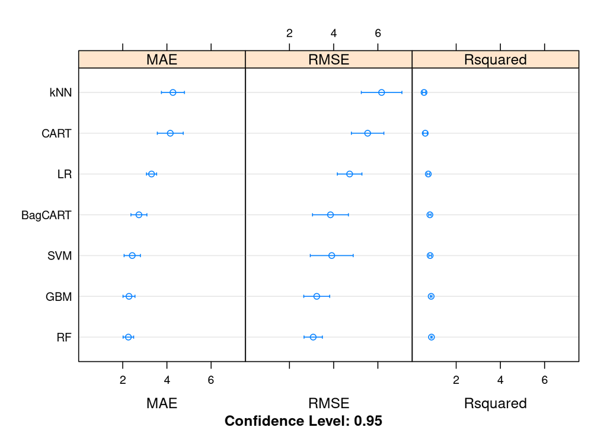

```r
dotplot(results)
```

```r
cat('The average RMSE from all models is:',
    mean(c(results$values$`LR~RMSE`,results$values$`CART~RMSE`,results$values$`kNN~RMSE`,results$values$`SVM~RMSE`,results$values$`BagCART~RMSE`,results$values$`RF~RMSE`,results$values$`GBM~RMSE`)))
```

```
## The average RMSE from all models is: 4.358697
```

## 5. Improve Accuracy or Results

After we achieve a short list of machine learning algorithms with good level of accuracy, we can leverage ways to improve the accuracy of the models.

### 5.a) Algorithm Tuning

```r
# Tuning algorithm #1 - Random Forest
email_notify(paste("Algorithm #1 tuning has begun!",date()))
```

```
## [1] "Java-Object{org.apache.commons.mail.SimpleEmail@6615435c}"
```

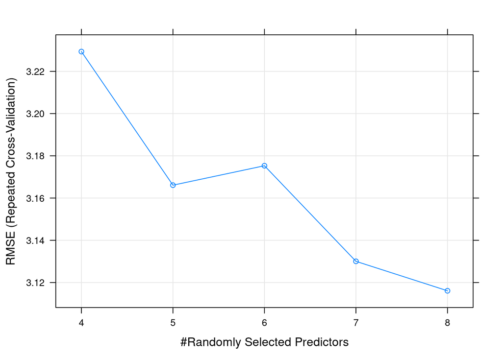

```r
startTimeModule <- proc.time()
set.seed(seedNum)
grid <- expand.grid(mtry = c(4:8))
fit.final1 <- train(targetVar~., data=xy_train, method="rf", metric=metricTarget, tuneGrid=grid, trControl=control)
plot(fit.final1)
```

```r
print(fit.final1)
```

```
## Random Forest
##
## 356 samples
##  13 predictor
##
## No pre-processing
## Resampling: Cross-Validated (10 fold, repeated 1 times)
## Summary of sample sizes: 320, 321, 322, 320, 320, 319, ...
## Resampling results across tuning parameters:
##
##   mtry  RMSE      Rsquared   MAE
##   4     3.229379  0.8788625  2.230130
##   5     3.166107  0.8830197  2.233050
##   6     3.175315  0.8802612  2.241853
##   7     3.130041  0.8829751  2.219969
##   8     3.116100  0.8828623  2.228237
##
## RMSE was used to select the optimal model using the smallest value.
## The final value used for the model was mtry = 8.
```

```r
proc.time()-startTimeModule
```

```
##    user  system elapsed
##  21.714   0.068  22.039
```

```r
email_notify(paste("Algorithm #1 tuning completed!",date()))
```

```
## [1] "Java-Object{org.apache.commons.mail.SimpleEmail@67b6d4ae}"
```

```r
# Tuning algorithm #2 - Stochastic Gradient Boosting
email_notify(paste("Algorithm #2 tuning has begun!",date()))
```

```
## [1] "Java-Object{org.apache.commons.mail.SimpleEmail@7225790e}"
```

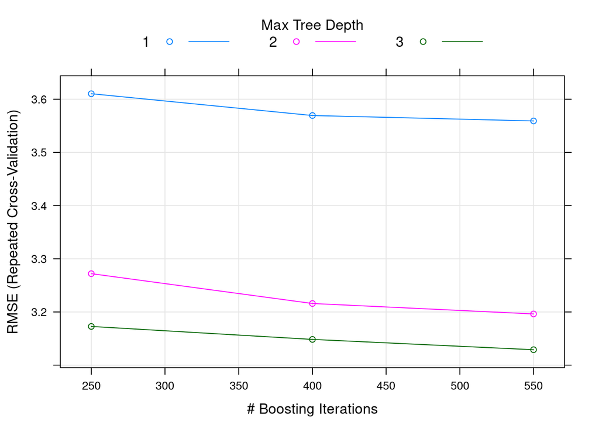

```r
startTimeModule <- proc.time()
set.seed(seedNum)
grid <- expand.grid(.n.trees=c(250, 400, 550), .shrinkage=0.1, .interaction.depth=c(1, 2, 3), .n.minobsinnode=10)
fit.final2 <- train(targetVar~., data=xy_train, method="gbm", metric=metricTarget, tuneGrid=grid, trControl=control, verbose=F)
plot(fit.final2)
```

```r
print(fit.final2)
```

```
## Stochastic Gradient Boosting
##
## 356 samples
##  13 predictor
##
## No pre-processing
## Resampling: Cross-Validated (10 fold, repeated 1 times)
## Summary of sample sizes: 320, 321, 322, 320, 320, 319, ...
## Resampling results across tuning parameters:
##
##   interaction.depth  n.trees  RMSE      Rsquared   MAE
##   1                  250      3.610348  0.8382627  2.545309
##   1                  400      3.569363  0.8442085  2.568008
##   1                  550      3.559155  0.8451486  2.558435
##   2                  250      3.271989  0.8666168  2.319953
##   2                  400      3.215916  0.8722035  2.286454
##   2                  550      3.196287  0.8733925  2.285416
##   3                  250      3.172748  0.8740367  2.270567
##   3                  400      3.148376  0.8753895  2.231611
##   3                  550      3.128982  0.8769107  2.213918
##
## Tuning parameter 'shrinkage' was held constant at a value of 0.1
##
## Tuning parameter 'n.minobsinnode' was held constant at a value of 10
## RMSE was used to select the optimal model using the smallest value.
## The final values used for the model were n.trees = 550,
##  interaction.depth = 3, shrinkage = 0.1 and n.minobsinnode = 10.
```

```r
proc.time()-startTimeModule
```

```
##    user  system elapsed
##   2.810   0.011   2.860
```

```r
email_notify(paste("Algorithm #2 tuning completed!",date()))
```

```
## [1] "Java-Object{org.apache.commons.mail.SimpleEmail@52af6cff}"
```

### 5.d) Compare Algorithms After Tuning

```r
results <- resamples(list(RF=fit.final1, GBM=fit.final2))
summary(results)
```

```
##
## Call:
## summary.resamples(object = results)
##
## Models: RF, GBM
## Number of resamples: 10
##
## MAE
##         Min.  1st Qu.   Median     Mean  3rd Qu.     Max. NA's
## RF  1.500965 2.082604 2.283173 2.228237 2.498362 2.661338    0
## GBM 1.523316 2.123786 2.274192 2.213918 2.413660 2.584530    0
##
## RMSE
##         Min.  1st Qu.   Median     Mean  3rd Qu.     Max. NA's
## RF  1.791603 2.734866 3.099309 3.116100 3.642255 4.210685    0
## GBM 1.846271 2.796405 3.194455 3.128982 3.494406 4.208885    0
##
## Rsquared
##          Min.   1st Qu.    Median      Mean   3rd Qu.      Max. NA's
## RF  0.8314059 0.8616853 0.8733674 0.8828623 0.9054914 0.9504493    0
## GBM 0.7972794 0.8417447 0.8778163 0.8769107 0.9157421 0.9348587    0
```

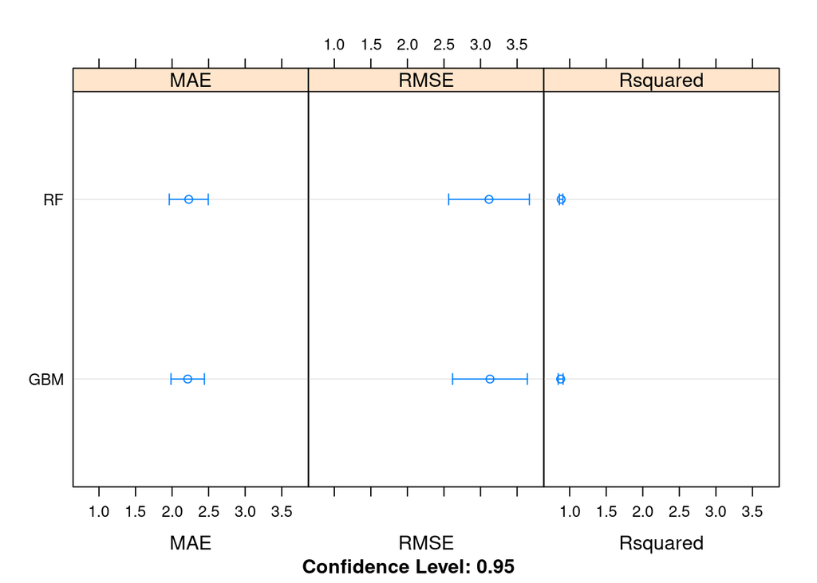

```r
dotplot(results)
```

## 6. Finalize Model and Present Results

Once we have narrow down to a model that we believe can make accurate predictions on unseen data, we are ready to finalize it. Finalizing a model may involve sub-tasks such as:

- Using an optimal model tuned to make predictions on unseen data.
- Creating a standalone model using the tuned parameters
- Saving an optimal model to file for later use.

```r
email_notify(paste("Model Validation and Final Model Creation has begun!",date()))
```

```
## [1] "Java-Object{org.apache.commons.mail.SimpleEmail@737996a0}"
```

### 6.a) Predictions on validation dataset

```r
predictions <- predict(fit.final2, newdata=xy_test)
print(RMSE(predictions, y_test))
```

```
## [1] 3.523829
```

```r
print(R2(predictions, y_test))
```

```
## [1] 0.8680863
```

### 6.b) Create standalone model on entire training dataset

```r
startTimeModule <- proc.time()
library(gbm)
set.seed(seedNum)

# Combining the training and test datasets to form the original dataset that will be used for training the final model
xy_train <- rbind(xy_train, xy_test)

finalModel <- gbm(targetVar~., data=xy_train, n.trees=550, shrinkage=0.1, interaction.depth=3, n.minobsinnode=10)
```

```
## Distribution not specified, assuming gaussian ...
```

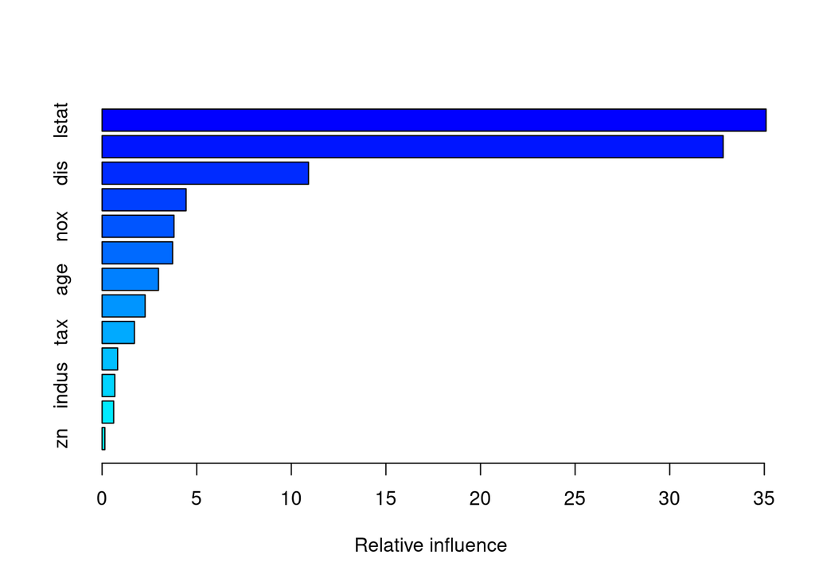

```
##             var    rel.inf
## lstat     lstat 35.0935695
## rm           rm 32.8244048
## dis         dis 10.9087097
## crim       crim  4.4379227
## nox         nox  3.7985439
## ptratio ptratio  3.7253202
## age         age  2.9802876
## b             b  2.2745834
## tax         tax  1.7082201
## chas       chas  0.8196011
## indus     indus  0.6717465
## rad         rad  0.6115125
## zn           zn  0.1455781
```

```r
summary(finalModel)
```

```r
proc.time()-startTimeModule
```

```
##    user  system elapsed
##   0.209   0.000   0.212
```

### 6.c) Save model for later use

```r
#saveRDS(finalModel, "./finalModel_Regression.rds")
```

```r
email_notify(paste("Model Validation and Final Model Creation Completed!",date()))
```

```
## [1] "Java-Object{org.apache.commons.mail.SimpleEmail@3dd3bcd}"
```

```r
proc.time()-startTimeScript
```

```
##    user  system elapsed
##  62.967   0.829 112.450
```